# About the data

For this problem set, we will apply unsupervised and supervised learning skills to develop a diagnostic model for hepatocellular carcinoma (HCC) from transcriptomics data. This dataset came from Gene Expression Omnibus GSE14520

We will also try to identify a small set of genes that are important for the diagnosis. This will let us develop a low-cost PCR or Nanostring assay (rather than performing microarray or RNA-seq on every new patient)

## Q1: Import packages that you need here

```python
import pandas as pd
import numpy as np
import matplotlib.pyplot as plt
import seaborn as sns
import scipy.stats
import umap
import statsmodels

from scipy.stats import ttest_ind
from statsmodels.stats.multitest import multipletests
from scipy.spatial.distance import pdist, squareform
from sklearn.preprocessing import StandardScaler
from sklearn.model_selection import train_test_split, StratifiedKFold, GridSearchCV
from sklearn.linear_model import LogisticRegression, Ridge, Lasso
from sklearn.decomposition import PCA
from sklearn.manifold import TSNE, MDS
from sklearn.metrics import classification_report, confusion_matrix, roc_curve, roc_auc_score
from sklearn.metrics import average_precision_score, precision_recall_curve
from sklearn.svm import SVR
```

## Q2: Use pandas's read_csv() to load the transcriptomics data

```python
data = pd.read_csv('Liver_GSE14520_U133A.csv', header = 0, index_col = 0)
data.head()
```

| samples | type | 1007_s_at | 1053_at | 117_at | 121_at | 1255_g_at | 1294_at | 1316_at | 1320_at | 1405_i_at | ... | AFFX-r2-Ec-bioD-3_at | AFFX-r2-Ec-bioD-5_at | AFFX-r2-P1-cre-3_at | AFFX-r2-P1-cre-5_at | AFFX-ThrX-3_at | AFFX-ThrX-5_at | AFFX-ThrX-M_at | AFFX-TrpnX-3_at | AFFX-TrpnX-5_at | AFFX-TrpnX-M_at |
| --- | --- | --- | --- | --- | --- | --- | --- | --- | --- | --- | --- | --- | --- | --- | --- | --- | --- | --- | --- | --- | --- |
| GSM362958.CEL.gz | HCC | 6.801198 | 4.553189 | 6.787790 | 5.430893 | 3.250222 | 6.272688 | 3.413405 | 3.374910 | 3.654116 | ... | 10.735084 | 10.398843 | 12.298551 | 12.270505 | 3.855588 | 3.148321 | 3.366087 | 3.199008 | 3.160388 | 3.366417 |
| GSM362959.CEL.gz | HCC | 7.585956 | 4.193540 | 3.763183 | 6.003593 | 3.309387 | 6.291927 | 3.754777 | 3.587603 | 5.137159 | ... | 11.528447 | 11.369919 | 12.867048 | 12.560433 | 4.016561 | 3.282867 | 3.541994 | 3.548680 | 3.460083 | 3.423348 |
| GSM362960.CEL.gz | HCC | 7.803370 | 4.134075 | 3.433113 | 5.395057 | 3.476944 | 5.825713 | 3.505036 | 3.687333 | 4.515175 | ... | 10.892460 | 10.416151 | 12.356337 | 11.888482 | 3.839367 | 3.598851 | 3.516791 | 3.484089 | 3.282626 | 3.512024 |
| GSM362964.CEL.gz | HCC | 6.920840 | 4.000651 | 3.754500 | 5.645297 | 3.387530 | 6.470458 | 3.629249 | 3.577534 | 5.192624 | ... | 10.686871 | 10.524836 | 12.006596 | 11.846195 | 3.867602 | 3.180472 | 3.309547 | 3.425501 | 3.166613 | 3.377499 |
| GSM362965.CEL.gz | HCC | 6.556480 | 4.599010 | 4.066155 | 6.344537 | 3.372081 | 5.439280 | 3.762213 | 3.440714 | 4.961625 | ... | 11.014454 | 10.775566 | 12.657182 | 12.573076 | 4.091440 | 3.306729 | 3.493704 | 3.205771 | 3.378567 | 3.392938 |

5 rows × 22278 columns

### Separate gene expression data and cancer labels

```python
exp_data = data.iloc[:,1:]
cancer_labels = data['type']
```

## Q3: Count the numbers of HCC and normal samples

```python
data['type'].value_counts()
```

```
HCC       181
normal    176
Name: type, dtype: int64
```

## Q4: Replace microarray probe IDs with gene symbols

1. Download probe ID mapping for platform GPL3921 from GEO (should be in .txt format)
2. Load the mapping file using pandas's **read_csv()**
   - You will need to adjust **header** and **sep** parameters to get the right data

```python
annot = pd.read_csv('GPL3921-25447.txt', header = 0, index_col = 0, comment='#', sep = '\t', encoding= 'unicode_escape')
annot.head(2)
```

| ID | GB_ACC | SPOT_ID | Species Scientific Name | Annotation Date | Sequence Type | Sequence Source | Target Description | Representative Public ID | Gene Title | Gene Symbol | ENTREZ_GENE_ID | RefSeq Transcript ID | Gene Ontology Biological Process | Gene Ontology Cellular Component | Gene Ontology Molecular Function |
| --- | --- | --- | --- | --- | --- | --- | --- | --- | --- | --- | --- | --- | --- | --- | --- |
| 1007_s_at | U48705 | NaN | Homo sapiens | Mar 8, 2007 | Exemplar sequence | NaN | U48705 /FEATURE=mRNA /DEFINITION=HSU48705 Huma... | U48705 | discoidin domain receptor family, member 1 | DDR1 | 780 | NM_001954 /// NM_013993 /// NM_013994 | 0006468 // protein amino acid phosphorylation ... | 0005615 // extracellular space // inferred fro... | 0000166 // nucleotide binding // inferred from... |
| 1053_at | M87338 | NaN | Homo sapiens | Mar 8, 2007 | Exemplar sequence | NaN | M87338 /FEATURE= /DEFINITION=HUMA1SBU Human re... | M87338 | replication factor C (activator 1) 2, 40kDa | RFC2 | 5982 | NM_002914 /// NM_181471 | 0006260 // DNA replication // inferred from el... | 0005634 // nucleus // inferred from electronic... | 0000166 // nucleotide binding // inferred from... |

1. Create a dictionary that map from probe ID to gene symbol

```python
probe_to_gene = {}

for probe_id in annot.index:
    if not pd.isna(annot.loc[probe_id, 'Gene Symbol']): ## ignore rows with missing gene symbol
        gene_symbol = annot.loc[probe_id, 'Gene Symbol'].split()[0] ## add .split()[0] because some rows contain multiple gene symbols
        probe_to_gene[probe_id] = gene_symbol
```

1. Apply the mapping to the column names

```python
probes_with_symbol = exp_data.columns ## create a list of probes that have associated gene symbols in probe_to_gene

selected_exp_data = exp_data.loc[:, probes_with_symbol].copy()
selected_exp_data = selected_exp_data.drop(list(set(list(probes_with_symbol)).difference(list(probe_to_gene.keys()))), axis = 1) # remove probe IDs which do not have gene symbols
selected_exp_data.columns = [probe_to_gene[x] for x in selected_exp_data.columns]
selected_exp_data.head(2)
```

| samples | DDR1 | RFC2 | HSPA6 | PAX8 | GUCA1A | UBE1L | THRA | PTPN21 | CCL5 | CYP2E1 | ... | ACTB | ACTB | ACTB | GAPDH | GAPDH | GAPDH | STAT1 | STAT1 | STAT1 | STAT1 |
| --- | --- | --- | --- | --- | --- | --- | --- | --- | --- | --- | --- | --- | --- | --- | --- | --- | --- | --- | --- | --- | --- |
| GSM362958.CEL.gz | 6.801198 | 4.553189 | 6.787790 | 5.430893 | 3.250222 | 6.272688 | 3.413405 | 3.374910 | 3.654116 | 3.804983 | ... | 12.600228 | 8.925829 | 10.577185 | 12.434618 | 10.053507 | 11.399226 | 8.887026 | 3.484061 | 5.223046 | 5.106557 |
| GSM362959.CEL.gz | 7.585956 | 4.193540 | 3.763183 | 6.003593 | 3.309387 | 6.291927 | 3.754777 | 3.587603 | 5.137159 | 8.622475 | ... | 12.611494 | 8.560630 | 10.242594 | 12.305758 | 9.534238 | 11.164706 | 8.902539 | 3.565290 | 5.336692 | 4.610203 |

2 rows × 21248 columns

## Q5: Add expression data of probes for the same gene together

Notice above that there are multiple columns for **ACTB**, **GAPDH**, and **STAT1**, for example

What's the number of distinct genes after merging?

Ans: 13050 genes

```python
selected_exp_data = selected_exp_data.groupby(by = selected_exp_data.columns, axis = 1).sum()
selected_exp_data.head(2)
```

| samples | 15E1.2 | 2'-PDE | 3.8-1 | 76P | A2BP1 | A2M | A4GALT | A4GNT | AAAS | AACS | ... | ZWILCH | ZWINT | ZXDA | ZXDB | ZXDC | ZYG11BL | ZYX | ZZEF1 | ZZZ3 | dJ222E13.2 |
| --- | --- | --- | --- | --- | --- | --- | --- | --- | --- | --- | --- | --- | --- | --- | --- | --- | --- | --- | --- | --- | --- |
| GSM362958.CEL.gz | 3.870310 | 3.311889 | 4.747052 | 9.043714 | 3.717045 | 11.112549 | 4.485970 | 3.321094 | 4.300481 | 5.624774 | ... | 4.029822 | 7.641718 | 7.100057 | 3.375232 | 5.291975 | 11.832534 | 14.397605 | 12.897710 | 6.012624 | 3.634114 |
| GSM362959.CEL.gz | 4.371433 | 3.398232 | 4.151997 | 9.022985 | 3.722853 | 11.851930 | 5.273009 | 3.434037 | 4.022482 | 5.932366 | ... | 4.092187 | 6.758915 | 7.379284 | 3.702564 | 5.881519 | 11.906985 | 15.125108 | 12.790615 | 5.420451 | 3.948451 |

2 rows × 13050 columns

```python
selected_exp_data.shape
```

```
(357, 13050)
```

## Q6: Visualize data distribution with PCA and UMAP

Don't forget to standardize your data first

```python
std_data = (selected_exp_data - selected_exp_data.mean()) / selected_exp_data.std()

pca = PCA(random_state = 25).fit(std_data)
pca_embed = pca.transform(std_data)

umap_embed = umap.UMAP(n_components = 2, n_neighbors = 25, random_state = 25).fit_transform(std_data) ## set n_neighbors = 25
```

### Color by HCC versus normal

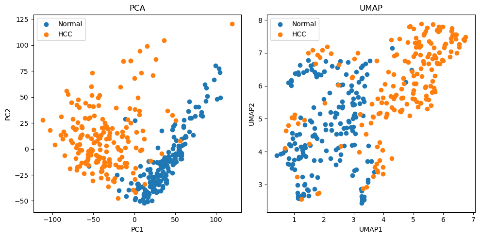

```python
plt.figure(figsize = (10, 5))

plt.subplot(1, 2, 1)
plt.scatter(pca_embed[cancer_labels == 'normal', 0], pca_embed[cancer_labels == 'normal', 1], label = 'Normal')
plt.scatter(pca_embed[cancer_labels == 'HCC', 0], pca_embed[cancer_labels == 'HCC', 1], label = 'HCC')
plt.xlabel('PC1'); plt.ylabel('PC2'); plt.legend(); plt.title('PCA')

plt.subplot(1, 2, 2)
plt.scatter(umap_embed[cancer_labels == 'normal', 0], umap_embed[cancer_labels == 'normal', 1], label = 'Normal') ## generate the same scatter plot with umap_embed
plt.scatter(umap_embed[cancer_labels == 'HCC', 0], umap_embed[cancer_labels == 'HCC', 1], label = 'HCC')
plt.xlabel('UMAP1'); plt.ylabel('UMAP2'); plt.legend(); plt.title('UMAP')

plt.tight_layout()
plt.show()
```

### What do these scatter plots tell you about the transcriptomics profiles for HCC vs normal?

Ans: Both PCA and UMAP revealed that there are clearly separated gene signatures between normal and HCC patients on the first axis of dimensionality reduction.

## Q7: Identify genes that are differentially expressed

This microarray dataset has been normalized and log-transformed. Hence, t-tests can be used

We are collecting the statistical test results in a new DataFrame with p-value and log FC

```python
ttest_results = pd.DataFrame(0, index = selected_exp_data.columns, columns = ['P-value', 'HCC/Normal Log FC'])

for gene in selected_exp_data.columns:
    normal_exp = selected_exp_data[gene].loc[cancer_labels == 'normal']
    cancer_exp = selected_exp_data[gene].loc[cancer_labels == 'HCC']

    ttest_results.loc[gene, 'P-value'] = ttest_ind(normal_exp, cancer_exp, equal_var = False, alternative = 'two-sided')[1]

    antilog_cancer_exp = cancer_exp**10 # Covert log-transformed values into original values before log2FC calculation
    antilog_normal_exp = normal_exp**10

    ttest_results.loc[gene, 'HCC/Normal Log FC'] = np.log2(antilog_cancer_exp.mean()/antilog_normal_exp.mean())

ttest_results.head()
```

|  | P-value | HCC/Normal Log FC |
| --- | --- | --- |
| 15E1.2 | 6.022727e-02 | 0.248011 |
| 2'-PDE | 3.878701e-01 | -0.300659 |
| 3.8-1 | 1.641268e-05 | -0.419890 |
| 76P | 7.473564e-10 | 0.709049 |
| A2BP1 | 3.304921e-02 | -0.169512 |

### Use statsmodels package to perform Benjamini-Yekutileli correction with FDR cutoff of 0.01

How many statistically significant DEGs are there?

Ans: 8046 genes

```python
by_result = multipletests(ttest_results['P-value'].values, method = 'fdr_by', alpha = 0.01)
by_filter = by_result[0]
print('number of significant DEGs:', sum(by_filter))
```

```
number of significant DEGs: 8046
```

### Let's apply fold change cutoff at 2-fold

How many statistically significant DEGs also have 2 or higher fold change (abs(log2FC) >= 1) across the two groups?

Ans: 3909 genes

```python
fc_filter = abs(ttest_results['HCC/Normal Log FC'].values) > 1
combined_filter = by_filter & fc_filter

print('number of significant DEGs with 2 or higher fold change:', sum(combined_filter))
```

```
number of significant DEGs with 2 or higher fold change: 3909
```

### Visualize volcano plot

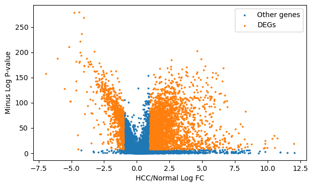

```python
plt.figure(figsize = (7, 4))

plt.scatter(ttest_results['HCC/Normal Log FC'].loc[~combined_filter], -np.log(ttest_results['P-value'].loc[~combined_filter]), s = 3, label = 'Other genes') ## plot all other genes
plt.scatter(ttest_results['HCC/Normal Log FC'].loc[combined_filter], -np.log(ttest_results['P-value'].loc[combined_filter]), s = 3, label = 'DEGs') ## plot only significant DEGs

plt.xlabel('HCC/Normal Log FC'); plt.ylabel('Minus Log P-value'); plt.legend()
plt.show()
```

## Q8: There is a gene with ~10 log FC but does not have as low p-value as other DEGs

Identify what gene it is and visualize its expression in HCC and normal group using violin plot

Ans: The gene is CHGB, with p-value and log2FC being 0.68 and 12.03, respectively.

```python
ttest_results.sort_values('HCC/Normal Log FC', ascending = False).head(3)
```

|  | P-value | HCC/Normal Log FC |
| --- | --- | --- |
| CHGB | 6.795709e-01 | 12.032256 |
| REG3A | 5.466522e-09 | 12.013142 |
| PCSK1 | 3.058982e-01 | 11.508859 |

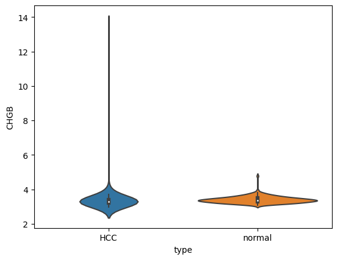

```python
_ = sns.violinplot(data = selected_exp_data, x = cancer_labels, y = 'CHGB') ## show violin plot for the top gene
```

### Compare the above pattern with another gene with the lowest p-value

Which gene has the lowest p-value? Visualize its expression in HCC and normal group using violin plot

Ans: The gene is VIPR1, with p-value and log2FC being 2.833721e-122 and -4.39, respectively.

```python
ttest_results.sort_values('P-value').head(3)
```

|  | P-value | HCC/Normal Log FC |
| --- | --- | --- |
| VIPR1 | 2.833721e-122 | -4.394819 |
| CXCL14 | 7.874903e-122 | -4.810839 |
| ECM1 | 3.334467e-117 | -4.061722 |

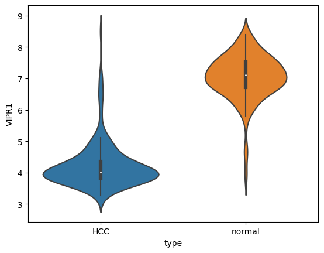

```python
_ = sns.violinplot(data = selected_exp_data, x = cancer_labels, y = 'VIPR1') ## show violin plot for the top gene
```

### Do the two violin plots agree with observed fold changes and p-values for these two genes?

Ans: The violin plot of CHGB in the HCC group seems to have outliers that cause log2FC more than the normal group. However, most values of the former are relatively equal to the latter's. Therefore, the difference of gene expression is nonsignificant. Besides, the violin plot of VIPR1 shows clearly considerable difference among the values, according to its significant p-value.

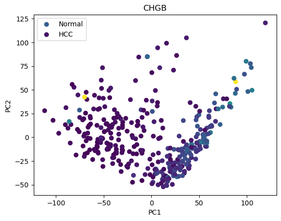

```python
plt.scatter(pca_embed[cancer_labels == 'normal', 0], pca_embed[cancer_labels == 'normal', 1], c = selected_exp_data.loc[cancer_labels == 'normal','CHGB'], label = 'Normal')
plt.scatter(pca_embed[cancer_labels == 'HCC', 0], pca_embed[cancer_labels == 'HCC', 1], c = selected_exp_data.loc[cancer_labels == 'HCC','CHGB'], label = 'HCC')
plt.xlabel('PC1'); plt.ylabel('PC2'); plt.legend(); plt.title('CHGB')
```

## Q9: Visualize the expression of these two genes on PCA and UMAP scatter plots

Use subplot to include all 4 scatters onto the same figure

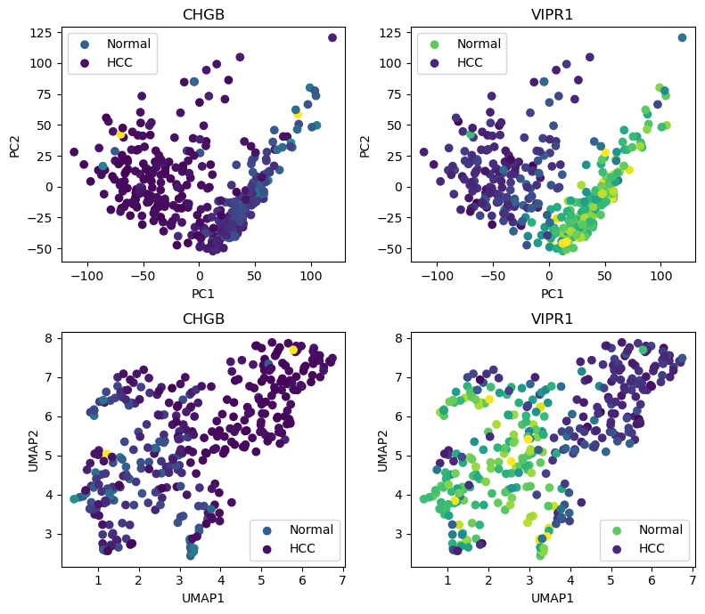

```python
plt.figure(figsize = (8, 7))

plt.subplot(2, 2, 1)
plt.scatter(pca_embed[cancer_labels == 'normal', 0], pca_embed[cancer_labels == 'normal', 1], c = selected_exp_data.loc[cancer_labels == 'normal', 'CHGB'], label = 'Normal')
plt.scatter(pca_embed[cancer_labels == 'HCC', 0], pca_embed[cancer_labels == 'HCC', 1], c = selected_exp_data.loc[cancer_labels == 'HCC', 'CHGB'], label = 'HCC')
plt.xlabel('PC1'); plt.ylabel('PC2'); plt.legend(); plt.title('CHGB')

plt.subplot(2, 2, 2)
plt.scatter(pca_embed[cancer_labels == 'normal', 0], pca_embed[cancer_labels == 'normal', 1], c = selected_exp_data.loc[cancer_labels == 'normal', 'VIPR1'], label = 'Normal')
plt.scatter(pca_embed[cancer_labels == 'HCC', 0], pca_embed[cancer_labels == 'HCC', 1], c = selected_exp_data.loc[cancer_labels == 'HCC', 'VIPR1'], label = 'HCC')
plt.xlabel('PC1'); plt.ylabel('PC2'); plt.legend(); plt.title('VIPR1')

plt.subplot(2, 2, 3)
plt.scatter(umap_embed[cancer_labels == 'normal', 0], umap_embed[cancer_labels == 'normal', 1], c = selected_exp_data.loc[cancer_labels == 'normal', 'CHGB'], label = 'Normal') ## generate the same scatter plot with umap_embed
plt.scatter(umap_embed[cancer_labels == 'HCC', 0], umap_embed[cancer_labels == 'HCC', 1], c = selected_exp_data.loc[cancer_labels == 'HCC', 'CHGB'], label = 'HCC')
plt.xlabel('UMAP1'); plt.ylabel('UMAP2'); plt.legend(); plt.title('CHGB')

plt.subplot(2, 2, 4)
plt.scatter(umap_embed[cancer_labels == 'normal', 0], umap_embed[cancer_labels == 'normal', 1], c = selected_exp_data.loc[cancer_labels == 'normal', 'VIPR1'], label = 'Normal') ## generate the same scatter plot with umap_embed
plt.scatter(umap_embed[cancer_labels == 'HCC', 0], umap_embed[cancer_labels == 'HCC', 1], c = selected_exp_data.loc[cancer_labels == 'HCC', 'VIPR1'], label = 'HCC')
plt.xlabel('UMAP1'); plt.ylabel('UMAP2'); plt.legend(); plt.title('VIPR1')

plt.tight_layout()
plt.show()
```

## Q10: Let's build a logistic regression model to diagnose HCC from normal

The required packages are imported for you

```python
from sklearn.linear_model import LogisticRegression
from sklearn.model_selection import StratifiedKFold, GridSearchCV

five_fold_splitter = StratifiedKFold(n_splits = 5, shuffle = True, random_state = 25) ## split data into 5 equal partitions
```

```python
x_train, x_test, y_train, y_test = train_test_split(std_data, cancer_labels, test_size = 0.2,
                                                    stratify = cancer_labels, shuffle = True, random_state = 25)
```

```python
y_train.value_counts()
```

```
HCC       144
normal    141
Name: type, dtype: int64
```

```python
y_test.value_counts()
```

```
HCC       37
normal    35
Name: type, dtype: int64
```

### Define the base model and use GridSearchCV to try every hyperparameter combination

Fit **GridSearchCV** on standardized data

```python
base_model = LogisticRegression(max_iter = 1000, solver = 'liblinear', random_state = 25) ## this is our base hyperparameters
hyperparameters = {'penalty': ['l1', 'l2'],
                   'C': [1e-5, 1e-4, 1e-3, 1e-2, 1e-1, 1, 10, 100]}

tuned_model = GridSearchCV(base_model, param_grid = hyperparameters, scoring = 'accuracy',
                           refit = True, cv = five_fold_splitter)
tuned_model.fit(x_train, y_train)
```

```
GridSearchCV(cv=StratifiedKFold(n_splits=5, random_state=25, shuffle=True),
             estimator=LogisticRegression(max_iter=1000, random_state=25,
                                          solver='liblinear'),
             param_grid={'C': [1e-05, 0.0001, 0.001, 0.01, 0.1, 1, 10, 100],
                         'penalty': ['l1', 'l2']},
             scoring='accuracy')
```

### View the top 5 hyperparameter sets

What is the best hyperparameter setting?

Ans: {'C': 0.01, 'penalty': 'l2'}

What is the achieved accuracy?

Ans: 0.978947

```python
tuned_result = pd.DataFrame.from_dict(tuned_model.cv_results_)
tuned_result = tuned_result.sort_values('rank_test_score')
tuned_result[['params', 'mean_test_score', 'std_test_score']].head(5)
```

|  | params | mean_test_score | std_test_score |
| --- | --- | --- | --- |
| 7 | {'C': 0.01, 'penalty': 'l2'} | 0.978947 | 0.013129 |
| 8 | {'C': 0.1, 'penalty': 'l1'} | 0.978947 | 0.013129 |
| 9 | {'C': 0.1, 'penalty': 'l2'} | 0.978947 | 0.013129 |
| 10 | {'C': 1, 'penalty': 'l1'} | 0.978947 | 0.013129 |
| 11 | {'C': 1, 'penalty': 'l2'} | 0.978947 | 0.013129 |

## Q11: Examine the coefficients to understand how the model works

Draw two scatter plots: one with **HCC/Normal Log FC** vs **Coefficient** and another with **-Log10 P-value** vs **Coefficient**

Does the model consistently assign large magnitude of coefficients (either positive or negative) to genes with high FCs or low p-values?

Ans: Yes but only in the relationship between coefficient and log2FC. For example, there is a negative relationship between coefficient and log2FC, with more negative coefficient leading to more positive log2FC and vice versa. The trend is unclear in the relationship between coefficient and negative log p-value although the larger negative and positive coefficient are related to high minus log p-values.

Can you explain why the model may behave the way it is?

Ans: Because log2FC has both negative and positive values, the model can classify the patient types according to the strong relationship between coefficient and log2FC. The p-values have only postive values, thus, the trend is not clear. Nevertheless, the model can capture some degree of larger minus log p-value (more significant p-value) in both negative and positive log2FC genes. Therefore, the scatter plot of minus Log P-value vs coefficient has biphasic appearance.

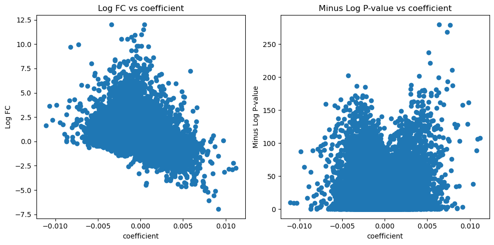

```python
model_coefficients = tuned_model.best_estimator_.coef_[0]

plt.figure(figsize = (10, 5))

plt.subplot(1, 2, 1) ## Log FC vs coefficient
plt.scatter(model_coefficients, ttest_results['HCC/Normal Log FC'])
plt.xlabel('coefficient'); plt.ylabel('Log FC'); plt.title('Log FC vs coefficient')

plt.subplot(1, 2, 2) ## Minus Log P-value vs coefficient
plt.scatter(model_coefficients, -np.log(ttest_results['P-value']))
plt.xlabel('coefficient'); plt.ylabel('Minus Log P-value'); plt.title('Minus Log P-value vs coefficient')

plt.tight_layout()
plt.show()
```

## Q12: We can help the model focus on DEGs by supplying only those genes as input

Select columns corresponding to DEGs from standardized data

```python
tuned_model.fit(std_data.loc[:,combined_filter], cancer_labels)
```

```
GridSearchCV(cv=StratifiedKFold(n_splits=5, random_state=25, shuffle=True),
             estimator=LogisticRegression(max_iter=1000, random_state=25,
                                          solver='liblinear'),
             param_grid={'C': [1e-05, 0.0001, 0.001, 0.01, 0.1, 1, 10, 100],
                         'penalty': ['l1', 'l2']},
             scoring='accuracy')
```

```python
new_tuned_result = pd.DataFrame.from_dict(tuned_model.cv_results_)
new_tuned_result = new_tuned_result.sort_values('rank_test_score')
new_tuned_result[['params', 'mean_test_score', 'std_test_score']].head(5)
```

|  | params | mean_test_score | std_test_score |
| --- | --- | --- | --- |
| 7 | {'C': 0.01, 'penalty': 'l2'} | 0.969288 | 0.020446 |
| 14 | {'C': 100, 'penalty': 'l1'} | 0.969288 | 0.020446 |
| 8 | {'C': 0.1, 'penalty': 'l1'} | 0.969249 | 0.018486 |
| 9 | {'C': 0.1, 'penalty': 'l2'} | 0.966510 | 0.022578 |
| 11 | {'C': 1, 'penalty': 'l2'} | 0.966510 | 0.022578 |

### Do we lose any performance by considering only DEGs as supposed to all genes?

Ans: Yes, considering only the DEGs decrease the performance score but slightly (0.978947 vs 0.969288)

## Q13: Try to reduce the number of input genes as much as possible

This will help us develop a gene panel for PCR or Nanostring (800 or less genes)

RFECV (Recursive Feature Elimination with Cross-Validation) iteratively remove gene(s) with the lowest impact on the model and measure the model performance

```python
from sklearn.feature_selection import RFECV
```

```python
rfe_result = RFECV(LogisticRegression(penalty = 'l2', C = 0.01, max_iter = 1000, solver = 'liblinear', random_state = 25),
                   step = 25, cv = five_fold_splitter, scoring = 'accuracy', n_jobs = 2)
rfe_result.fit(std_data.loc[:, combined_filter], cancer_labels)
```

```
RFECV(cv=StratifiedKFold(n_splits=5, random_state=25, shuffle=True),
      estimator=LogisticRegression(C=0.01, max_iter=1000, random_state=25,
                                   solver='liblinear'),
      n_jobs=2, scoring='accuracy', step=25)
```

### Line plot showing the accuracy as more genes were discarded from the input

As low as 100 genes is enough to achieve 96% accuracy. We can reduce the genes further but the code may run a lot longer

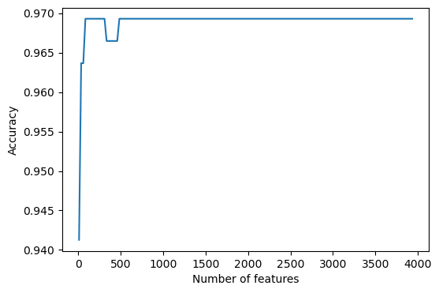

```python
plt.figure(figsize = (6, 4))
plt.plot((combined_filter.sum() % 25) + 25 * np.arange(len(rfe_result.cv_results_['mean_test_score'])),
         rfe_result.cv_results_['mean_test_score'])
plt.xlabel('Number of features'); plt.ylabel('Accuracy')
plt.show()
```

```python
optimal_genes = std_data.columns[combined_filter][rfe_result.support_]
print(optimal_genes)
```

```
Index(['ACTN4', 'B3GAT1', 'C1RL', 'C20orf27', 'C9orf68', 'CAP2', 'CCS', 'CD1D',
       'CD34', 'CDC37L1', 'CHST4', 'CLEC1B', 'CLEC4M', 'CSAD', 'CYP2C18',
       'CYP4F12', 'DDX10', 'DNAJC12', 'DRAP1', 'DYNLRB1', 'EPB41L4B', 'FCN2',
       'FLJ43663', 'FOS', 'GABRP', 'GLUL', 'GMPPA', 'HAMP', 'HBA1', 'HBA2',
       'HBB', 'HMGB2', 'HPS5', 'ID1', 'IGFBP3', 'IGJ', 'IL1RAP', 'KCNJ15',
       'KCNN2', 'KMO', 'LPAL2', 'MEA1', 'MYOM2', 'NDEL1', 'NGFR', 'OAT',
       'PCLKC', 'PER1', 'RAB26', 'RBX1', 'RFX5', 'SLC23A2', 'SRD5A2', 'STAB2',
       'TENC1', 'TP53I3', 'TRGC2', 'XLKD1', 'ZFP36'],
      dtype='object')
```

### Visualize the position of these genes on volcano plot

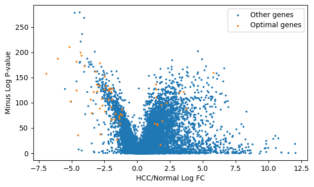

```python
plt.figure(figsize = (7, 4))

plt.scatter(ttest_results['HCC/Normal Log FC'].loc[list(set(list(ttest_results.index)).difference(list(optimal_genes)))], -np.log(ttest_results['P-value'].loc[list(set(list(ttest_results.index)).difference(list(optimal_genes)))]), s = 3, label = 'Other genes') ## plot all other genes
plt.scatter(ttest_results['HCC/Normal Log FC'].loc[optimal_genes], -np.log(ttest_results['P-value'].loc[optimal_genes]), s = 3, label = 'Optimal genes') ## plot only optimal genes

plt.xlabel('HCC/Normal Log FC'); plt.ylabel('Minus Log P-value'); plt.legend()
plt.show()
```

# Congratulations for reaching the end of this year's problem set!!